# Data exploration

Przemyslaw Biecek, Anna Wróblewska

Data Mining - Advances

# Introduction

In this part we are going to cover following topics:

- how to read data into R
- how to present basic summaries for a single variable
- how to present summaries for pairs of variables

We are going to work with three datasets: `GermanCredit` from `caret` package, `pancan` from csv/xlsx file, `iris` from `datasets` package.

# Loading data

You may read data from many different formats into the R. Let’s cover three typical use cases.

## Data from core packages

For datasets that are available in core packages (i.e. `base`, `datasets`) it’s enough to use the `data()` function in order to load the data into the namespace.

Here we are going to load famous Anderson’s iris data.

```r
data(iris)
head(iris)
```

```
##   Sepal.Length Sepal.Width Petal.Length Petal.Width Species
## 1          5.1         3.5          1.4         0.2  setosa
## 2          4.9         3.0          1.4         0.2  setosa
## 3          4.7         3.2          1.3         0.2  setosa
## 4          4.6         3.1          1.5         0.2  setosa
## 5          5.0         3.6          1.4         0.2  setosa
## 6          5.4         3.9          1.7         0.4  setosa
```

## Data from additional packages

For datasets that are available in other packages load the package and then all datasets are available. Note that you should install the package first. Use `install.packages(“caret”)` for example.

```r
library(PogromcyDanych)
```

```r
library(maps)
data(countries)
head(countries)
```

```
##               country birth.rate death.rate population continent
## 1         Afghanistan       34.1        7.7      30552      Asia
## 2             Albania       12.9        9.4       3173    Europe
## 3             Algeria       24.3        5.7      39208    Africa
## 4             Andorra        8.9        8.4         79    Europe
## 5              Angola       44.1       13.9      21472    Africa
## 6 Antigua and Barbuda       16.5        6.8         90  Americas
```

```r
library(caret)
data(GermanCredit)
head(GermanCredit[,1:10])
```

```
##   Duration Amount InstallmentRatePercentage ResidenceDuration Age
## 1        6   1169                         4                 4  67
## 2       48   5951                         2                 2  22
## 3       12   2096                         2                 3  49
## 4       42   7882                         2                 4  45
## 5       24   4870                         3                 4  53
## 6       36   9055                         2                 4  35
##   NumberExistingCredits NumberPeopleMaintenance Telephone ForeignWorker
## 1                     2                       1         0             1
## 2                     1                       1         1             1
## 3                     1                       2         1             1
## 4                     1                       2         1             1
## 5                     2                       2         1             1
## 6                     1                       2         0             1
##   Class
## 1  Good
## 2   Bad
## 3  Good
## 4  Good
## 5   Bad
## 6  Good
```

## Data from cvs/rda/xlsx files

Use `read.table{}` or `read.xlsx{openxlsx}` in order to read data from csv/xlsx files. Use `load{}` function in order to load data from binary rda files.

Here we are going to read data from The Cancer Genome Atlas. For 5 different cancers we have information about expressions of 31 different genes.

```r
load("pancan.rda")
pancan <- read.table("pancan.csv", header=TRUE, sep=";")
library(openxlsx)
pancan <- read.xlsx("pancan.xlsx",sheet = 1)

head(pancan)
```

```
##                     disease gender ARHGAP8 ATP5EP2 C15orf21 CLDN3
## 1 breast invasive carcinoma   MALE    1.63    0.13    -0.05 -0.57
## 2 breast invasive carcinoma   MALE   -0.06    1.10     1.44 -0.05
## 3 breast invasive carcinoma   MALE    1.24    1.51    -0.02  2.03
## 4 breast invasive carcinoma   MALE   -0.02   -0.73     0.22 -0.98
## 5 breast invasive carcinoma   MALE   -0.49    0.40     0.02  0.54
## 6 breast invasive carcinoma   MALE    0.54   -0.40     0.29 -0.09
##       CLDN4  CRB3  CUBN EEF1A1P9  ELF3 ENPEP EPCAM EPHA1 FTHL3 GATA3 H3F3C
## 1 -0.102684  0.12  0.53    -0.16 -1.27  0.50 -0.50  0.47 -1.13  6.99  0.75
## 2 -0.692684 -0.07  0.13     0.33  0.79  1.50 -0.60 -0.33 -0.42  7.57  0.97
## 3  0.517316  0.74 -0.45    -0.80 -1.27 -0.62  0.07 -0.18 -0.42  7.70  1.50
## 4 -1.012684 -0.02 -0.51    -0.09 -0.44  0.45 -0.17 -0.31 -1.49  6.89  0.45
## 5 -0.302684  0.17 -0.30    -0.07  1.18  0.56 -0.51 -0.28  1.28  7.03  1.15
## 6 -0.652684 -0.27 -0.80    -0.06 -1.29 -0.83 -0.32  0.33  0.07  7.23 -0.33
##   HNRNPA1L2     KRT18  KRT8 NBPF10 NCRNA00182  PAX8     PGAM4 RGPD4
## 1      0.01  1.570442  1.71   1.49     -0.289  0.36 -0.939953  0.42
## 2      0.38  0.340442 -0.06   1.61      0.821  0.15 -0.099952 -0.15
## 3      0.39  2.750442  2.84  -0.80     -0.309  1.26 -0.259952 -0.53
## 4      0.29  0.700442  0.48   2.39      0.401 -0.88 -0.389952  0.10
## 5      0.00  1.240442  2.07   1.02     -0.289 -3.24  0.450048 -0.54
## 6      0.60 -0.239558 -0.01   1.98     -0.139  0.97 -0.659953  0.23
##   RPL13AP20  RPL7 RPSAP9 SH2D3A SOX17 SPINT1 TMEM30B  TNK1
## 1    -0.675  0.08  -0.74   0.13 -0.29   0.44    0.79  1.38
## 2     0.025 -0.47   0.08   0.52  0.64  -0.69    1.41 -0.34
## 3     0.795  0.10   0.02   0.09 -0.25   0.18    0.51  0.25
## 4    -0.895 -0.52  -1.24  -0.91 -0.44   0.11    0.46  1.71
## 5    -0.345 -0.27   0.98   0.64  1.72   0.26    1.33 -0.36
## 6     0.325  0.47  -0.39  -0.97 -1.80  -0.81    0.28 -1.71
```

Here are student alcohol consumption data from http://archive.ics.uci.edu/ml/datasets/STUDENT+ALCOHOL+CONSUMPTION

```r
student_mat <- read.table("student-mat.csv",sep=";",header=TRUE)
nrow(student_mat)
```

```
## [1] 395
```

```r
student_por <- read.xlsx("student-por.xlsx",sheet=1)
head(student_por)
```

```
##   school sex age address famsize Pstatus Medu Fedu     Mjob     Fjob
## 1     GP   F  18       U     GT3       A    4    4  at_home  teacher
## 2     GP   F  17       U     GT3       T    1    1  at_home    other
## 3     GP   F  15       U     LE3       T    1    1  at_home    other
## 4     GP   F  15       U     GT3       T    4    2   health services
## 5     GP   F  16       U     GT3       T    3    3    other    other
## 6     GP   M  16       U     LE3       T    4    3 services    other
##       reason guardian traveltime studytime failures schoolsup famsup paid
## 1     course   mother          2         2        0       yes     no   no
## 2     course   father          1         2        0        no    yes   no
## 3      other   mother          1         2        0       yes     no   no
## 4       home   mother          1         3        0        no    yes   no
## 5       home   father          1         2        0        no    yes   no
## 6 reputation   mother          1         2        0        no    yes   no
##   activities nursery higher internet romantic famrel freetime goout Dalc
## 1         no     yes    yes       no       no      4        3     4    1
## 2         no      no    yes      yes       no      5        3     3    1
## 3         no     yes    yes      yes       no      4        3     2    2
## 4        yes     yes    yes      yes      yes      3        2     2    1
## 5         no     yes    yes       no       no      4        3     2    1
## 6        yes     yes    yes      yes       no      5        4     2    1
##   Walc health absences G1 G2 G3
## 1    1      3        4  0 11 11
## 2    1      3        2  9 11 11
## 3    3      3        6 12 13 12
## 4    1      5        0 14 14 14
## 5    2      5        0 11 13 13
## 6    2      5        6 12 12 13
```

# Summaries for one variable

## Numerical summaries for one variable

Let’s start with contingency tables for categorical variables like `disease` or `gender` from the `pancan` dataset.

The `table()` function calculates contingency tables for given variable.

```r
# species in the iris dataset
table(iris$Species)
```

```
##
##     setosa versicolor  virginica
##         50         50         50
```

```r
# classes of credit Good/Bad
table(GermanCredit$Class)
```

```
##
##  Bad Good
##  300  700
```

```r
# diseases/genders in pancan dataset
table(pancan$disease)
```

```
##
##             breast invasive carcinoma
##                                   806
##               glioblastoma multiforme
##                                   110
##           kidney clear cell carcinoma
##                                   454
##     ovarian serous cystadenocarcinoma
##                                   218
## uterine corpus endometrioid carcinoma
##                                   356
```

```r
table(pancan$gender)
```

```
##
## FEMALE   MALE
##   1568    376
```

```r
# diseases/genders in pancan dataset
# sex/work day alcohol consumption Dalc in student dataset
table(student_por$sex)
```

```
##
##   F   M
## 383 266
```

```r
table(student_por$Dalc)
```

```
##
##   1   2   3   4   5
## 451 121  43  17  17
```

For continuous variable one can use the `summary()` function.

```r
# 5 quartiles and mean for Sepal.Length
summary(iris$Sepal.Length)
```

```
##    Min. 1st Qu.  Median    Mean 3rd Qu.    Max.
##   4.300   5.100   5.800   5.843   6.400   7.900
```

```r
# Age for German Credit data
summary(GermanCredit$Age)
```

```
##    Min. 1st Qu.  Median    Mean 3rd Qu.    Max.
##   19.00   27.00   33.00   35.55   42.00   75.00
```

```r
# students absences
summary(student_por$absence)
```

```
##    Min. 1st Qu.  Median    Mean 3rd Qu.    Max.
##   0.000   0.000   2.000   3.659   6.000  32.000
```

```r
summary(pancan$PAX8)
```

```
##    Min. 1st Qu.  Median    Mean 3rd Qu.    Max.
##  -6.990  -1.505   3.095   1.956   5.460   8.644
```

## Graphical summaries for one variable

In many cases it is a good idea to present summaries graphically.

Contingency tables may be presented by barplots. Play with additional arguments like `horiz` or `las` to get nicer plot.

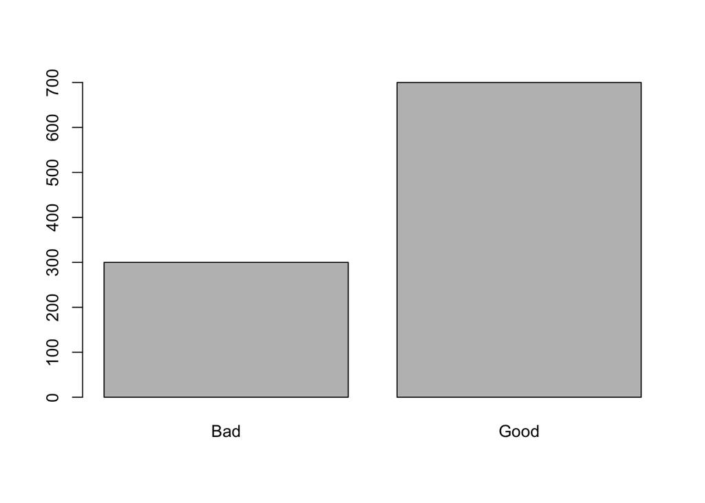

```r
# classes of credit Good/Bad
tab_credits <- table(GermanCredit$Class)
barplot(tab_credits)
```

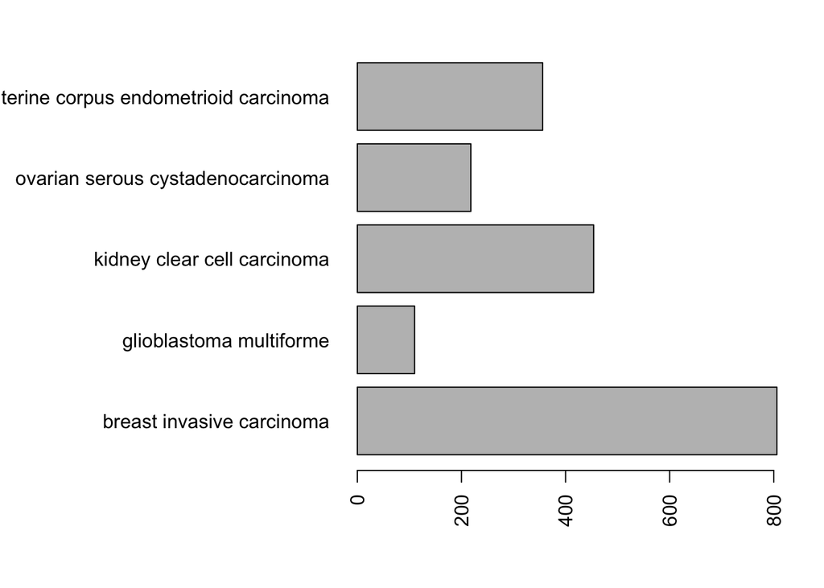

```r
# diseases/genders in pancan dataset
tab_disease <- table(pancan$disease)
par(mar=c(5,15,2,2))
barplot(tab_disease, horiz = TRUE, las=2)
```

For continuous variable the variable distribution may be presented with histograms `hist()` or boxplots `boxplot()`.

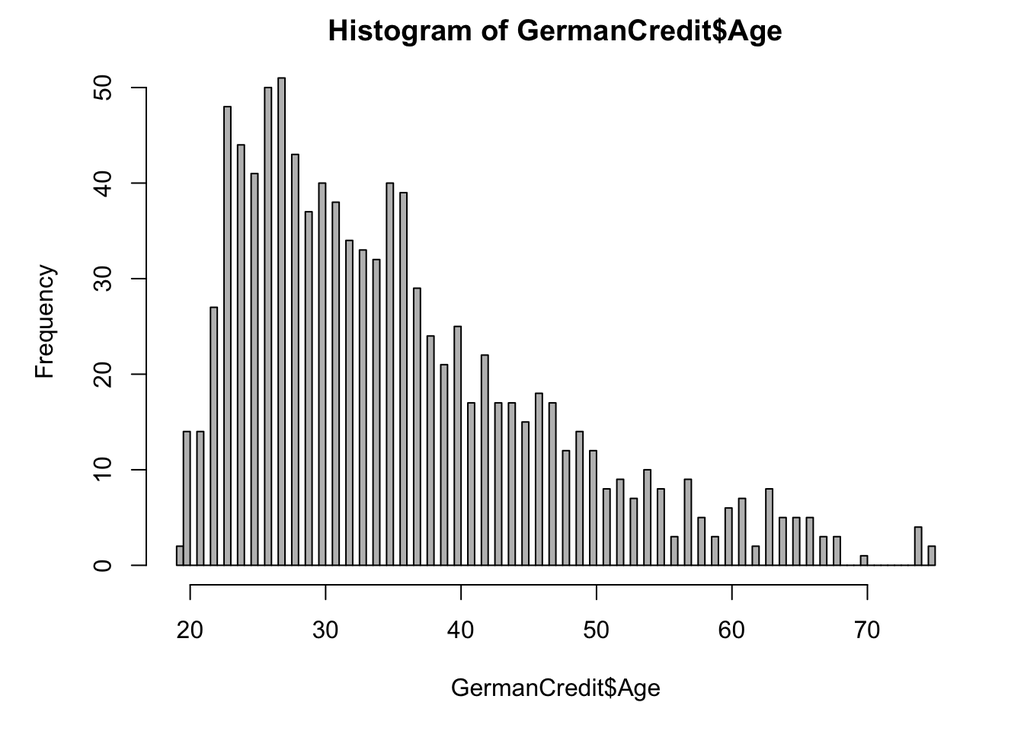

```r
# Age for German Credit data
par(mar=c(5,5,2,2))
hist(GermanCredit$Age, 100, col="grey")
```

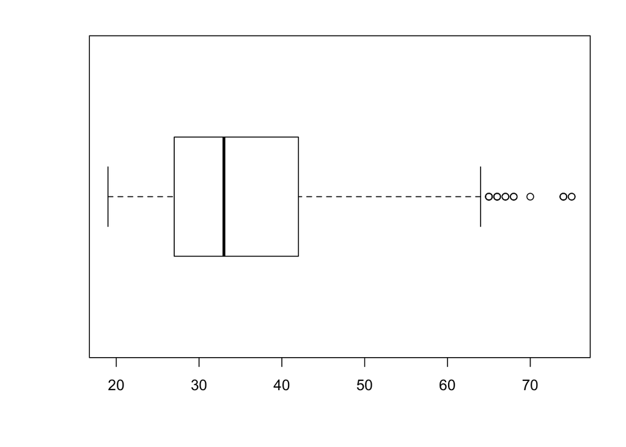

```r
boxplot(GermanCredit$Age, horizontal = TRUE)
```

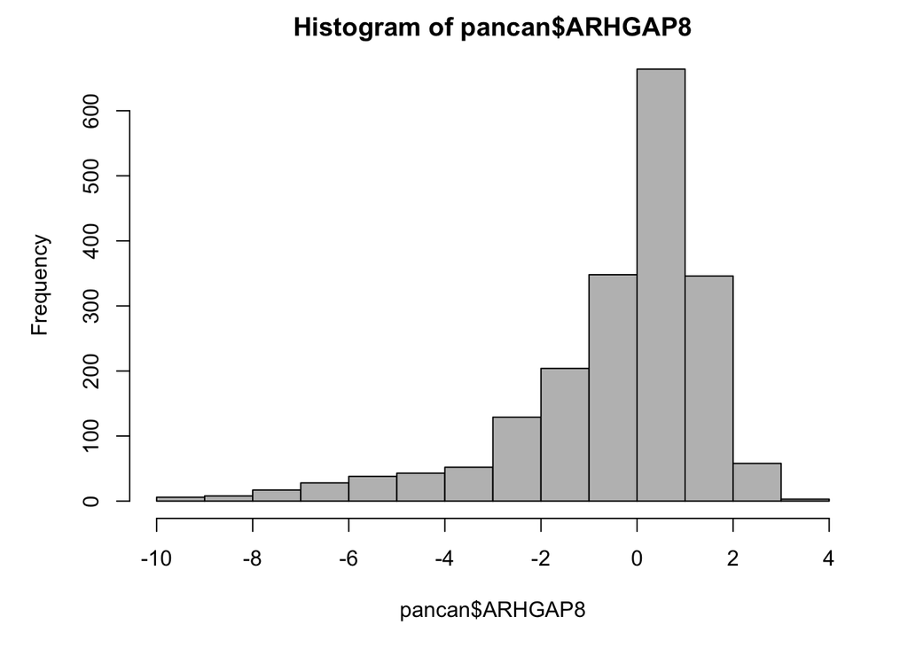

```r
# expression for selected genes
hist(pancan$ARHGAP8, col="grey")
```

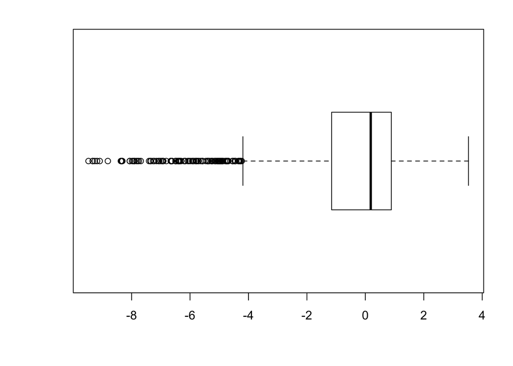

```r
boxplot(pancan$ARHGAP8, horizontal = TRUE)
```

# Summaries for two variables

## Numerical summaries for two variables

The `table()` function may be used for two categorical variables as well.

Use `prop.table()` to calculate proportions in rows / columns.

```r
# classes of credit Good/Bad
tab <- table(GermanCredit$Class, GermanCredit$Personal.Male.Single)
tab
```

```
##
##          0   1
##   Bad  154 146
##   Good 298 402
```

```r
prop.table(tab, 1)
```

```
##
##                0         1
##   Bad  0.5133333 0.4866667
##   Good 0.4257143 0.5742857
```

```r
# Dalc/genders in pancan dataset
tab2 <- table(student_por$Dalc, student_por$sex)
tab2
```

```
##
##       F   M
##   1 305 146
##   2  58  63
##   3  11  32
##   4   7  10
##   5   2  15
```

```r
round(100*prop.table(tab2, 1),1)
```

```
##
##        F    M
##   1 67.6 32.4
##   2 47.9 52.1
##   3 25.6 74.4
##   4 41.2 58.8
##   5 11.8 88.2
```

Use `by()` function to calculate summaries for different sub-groups.

```r
# Age for German Credit data
by(GermanCredit$Age, GermanCredit$Class, summary)
```

```
## GermanCredit$Class: Bad
##    Min. 1st Qu.  Median    Mean 3rd Qu.    Max.
##   19.00   25.00   31.00   33.96   40.00   74.00
## --------------------------------------------------------
## GermanCredit$Class: Good
##    Min. 1st Qu.  Median    Mean 3rd Qu.    Max.
##   19.00   27.00   34.00   36.22   42.25   75.00
```

```r
# expression for selected genes
by(pancan$ARHGAP8, pancan$disease, summary)
```

```
## pancan$disease: breast invasive carcinoma
##    Min. 1st Qu.  Median    Mean 3rd Qu.    Max.
## -4.0200 -0.1100  0.4500  0.4136  0.9400  3.1900
## --------------------------------------------------------
## pancan$disease: glioblastoma multiforme
##    Min. 1st Qu.  Median    Mean 3rd Qu.    Max.
##  -9.475  -7.129  -6.190  -6.239  -5.034  -3.383
## --------------------------------------------------------
## pancan$disease: kidney clear cell carcinoma
##    Min. 1st Qu.  Median    Mean 3rd Qu.    Max.
##  -5.730  -2.510  -1.850  -1.937  -1.182   2.910
## --------------------------------------------------------
## pancan$disease: ovarian serous cystadenocarcinoma
##     Min.  1st Qu.   Median     Mean  3rd Qu.     Max.
## -5.64000  0.02205  0.50460  0.41560  0.86960  2.23000
## --------------------------------------------------------
## pancan$disease: uterine corpus endometrioid carcinoma
##    Min. 1st Qu.  Median    Mean 3rd Qu.    Max.
## -4.7500  0.6046  1.0500  1.0170  1.5120  3.5300
```

## Graphical summaries for two variables

Two dimensional contingency tables may be presented with mosaicplots. They are not easy to read but very useful.

```r
tab <- table(GermanCredit$Class, GermanCredit$Personal.Male.Single)
tab
```

```
##
##          0   1
##   Bad  154 146
##   Good 298 402
```

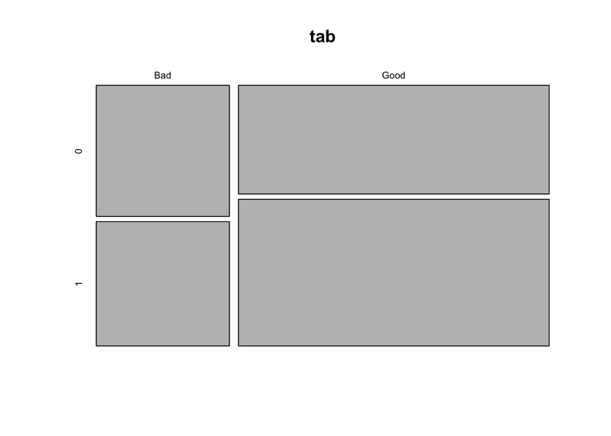

```r
mosaicplot(tab)
```

```r
# diseases/genders in pancan dataset
tab2 <- table(pancan$disease, pancan$gender)
tab2
```

```
##
##                                         FEMALE MALE
##   breast invasive carcinoma                797    9
##   glioblastoma multiforme                   37   73
##   kidney clear cell carcinoma              160  294
##   ovarian serous cystadenocarcinoma        218    0
##   uterine corpus endometrioid carcinoma    356    0
```

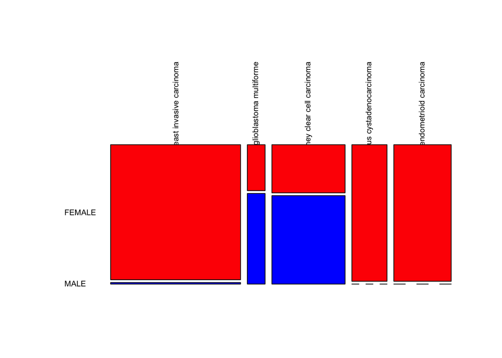

```r
mosaicplot(tab2, las=2, main="", color = c("red", "blue"))
```

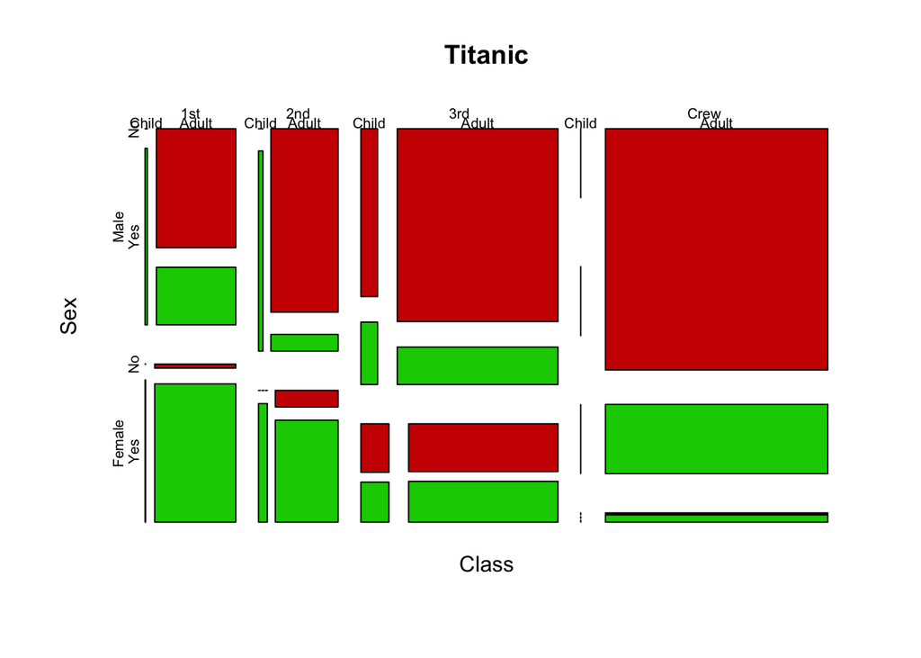

```r
mosaicplot(Titanic, color=c("red3", "green3"))
```

For continuous variable boxplots (`boxplot()`) are very good for making comparisons. Try `vioplot{vioplot}` if you are not scared by densities.

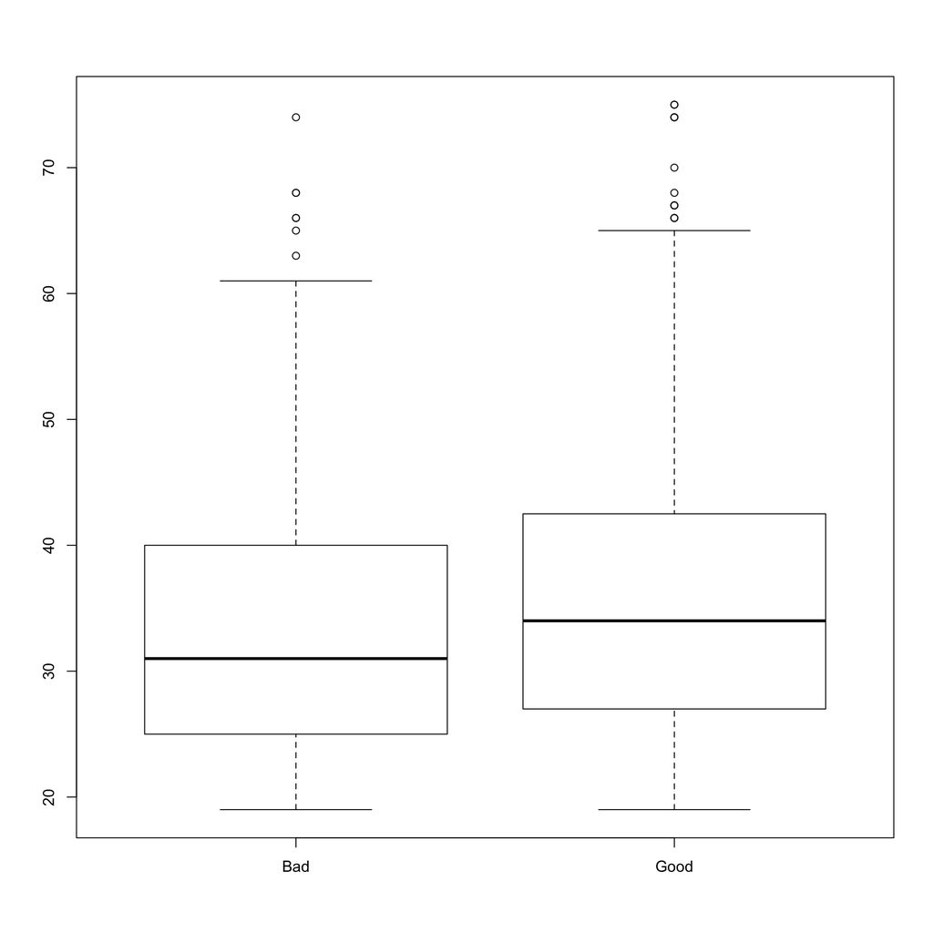

```r
# Age for German Credit data
boxplot(GermanCredit$Age ~ GermanCredit$Class)
```

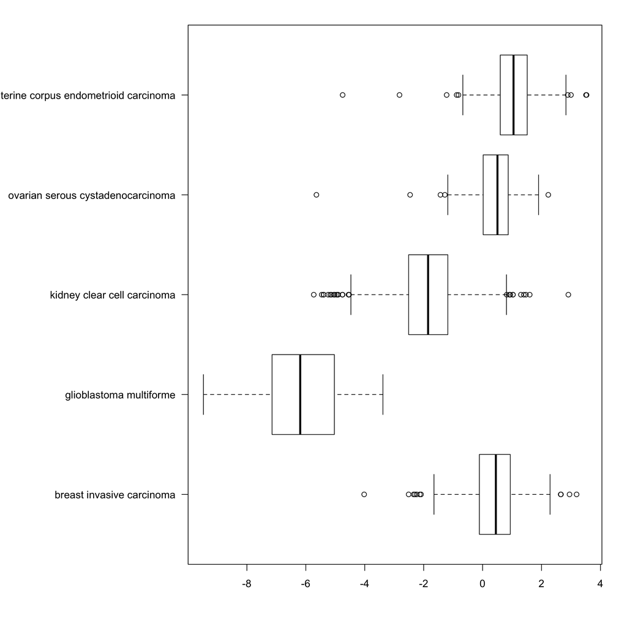

```r
# expression for selected genes
par(mar=c(5,15,2,2))
boxplot(pancan$ARHGAP8 ~ pancan$disease, horizontal = TRUE, las=1)
```

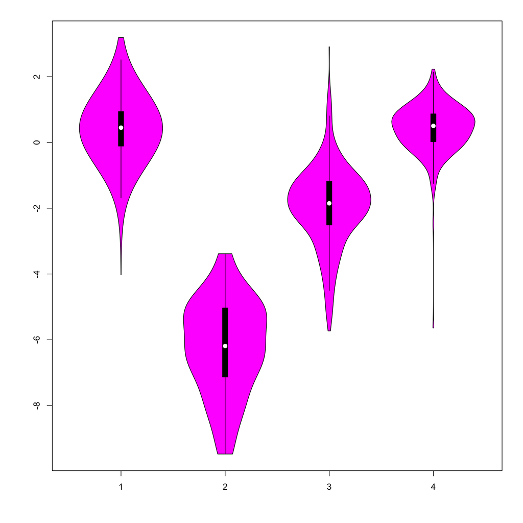

```r
library(vioplot)
par(mar=c(5,5,2,2))
vioplot(pancan$ARHGAP8[pancan$disease == "breast invasive carcinoma"],
        pancan$ARHGAP8[pancan$disease == "glioblastoma multiforme"],
        pancan$ARHGAP8[pancan$disease == "kidney clear cell carcinoma"],
        pancan$ARHGAP8[pancan$disease == "ovarian serous cystadenocarcinoma"])
```

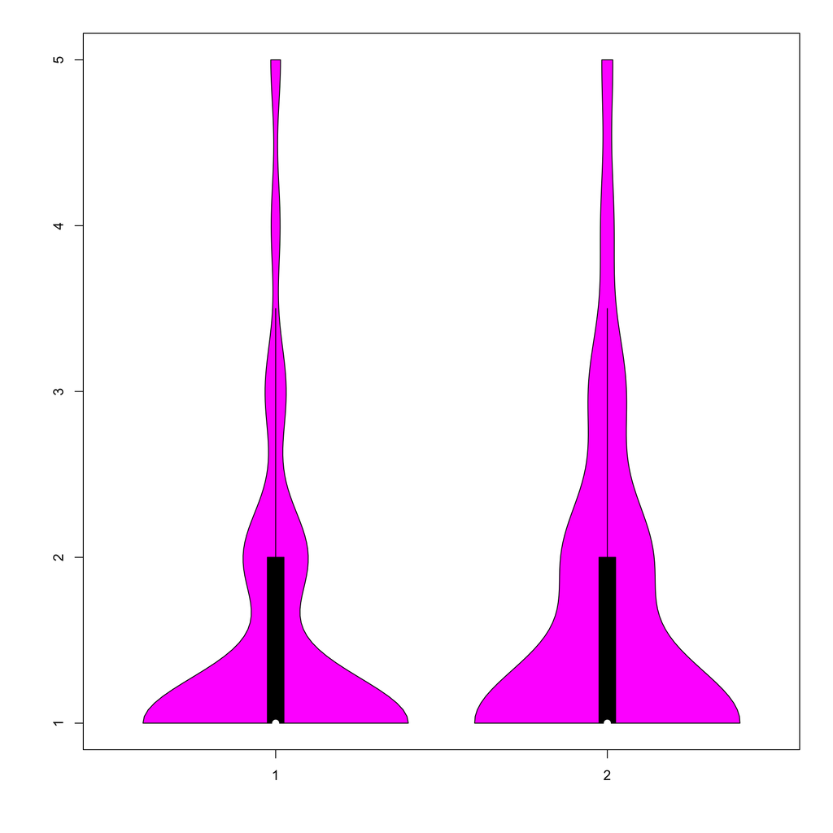

```r
vioplot(student_por$Dalc[student_por$famsize=="GT3"],
        student_por$Dalc[student_por$famsize=="LE3"])
```

# Computer classes

1. Read files: (`allegro-api-transactions.csv`)[https://www.dropbox.com/s/360xhh2d9lnaek3/allegro-api-transactions.csv?dl=0] and `allegro-categories-eng.txt`.
2. Merge the files to translate main_category names. (`merge`, `join` in `library(dplyr)`)
3. For the dataset present numerical and graphical summaries for following variables: `price`, `it_is_allegro_standard`, `it_is_brand_zone`, `it_seller_rating`, `date`.
4. Create a report in `knitr` with these summaries. Use only top 5 transactional main categories and compere the gmv=sum(price) to the overall gmv in one day.

# Home work

1. Load the `PogromcyDanych` package.
2. Use the `setLang()` function to translate columns names into English.
3. For the dataset `skiJumps2013` present numerical and graphical summaries for following variables: jumpSpeed, jumpDistance, compCountry, jumperCountry, jumperDateOfBirth.
4. Create a report in `knitr` with these summaries. Use only competitions in 2014 year.